# PaleoACES

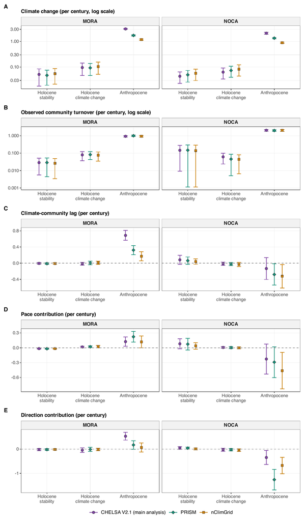

**Fig. S26. Rates of climate change, community turnover, the climate–community lag, and the pace and direction contributions by period type, with the three climate products.** Estimated means with 95% confidence intervals for the Holocene stability periods, the Holocene climate-change periods and the Anthropocene plot pairs of each park, from the models of Fig. 5 fitted with each product: (A) the climate change rate (SD of the legacy plots per century) and (B) the observed community turnover rate (CCA distance per century), both on log axes, where an interval that reaches zero or below is cut at the lower edge of the panel; (C) the lag rate, (D) the pace contribution and (E) the direction contribution, in CCA distance per century. Purple circles: CHELSA V2.1 (main analysis). Green diamonds: PRISM. Orange squares: nClimGrid. Script: `R/figures/supp_climate_product_sensitivity.R`.

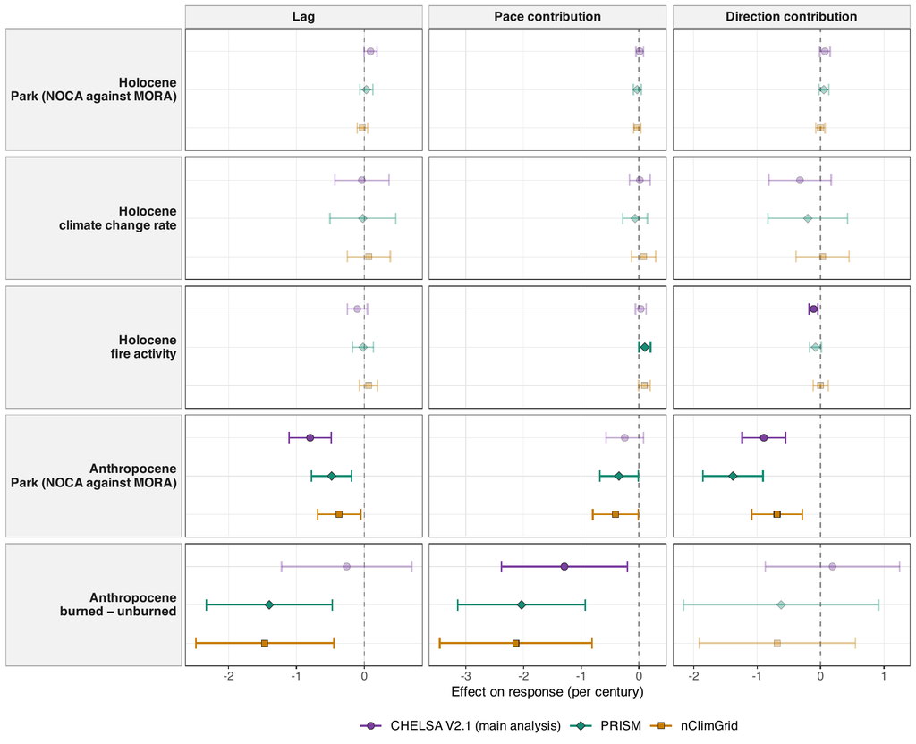

**Fig. S27. Associations with climate change and fire, with the three climate products.** Coefficients of Fig. 6 with their 95% confidence intervals, from the models fitted with each product. Rows: the terms of the Holocene models of the lake-periods (park, climate change rate, fire activity) and of the Anthropocene models of the plot pairs (park, burned between the surveys). Columns: the lag, the pace contribution and the direction contribution, per century. Coefficients whose interval includes zero are faded. The dashed vertical line marks zero. Purple circles: CHELSA V2.1 (main analysis). Green diamonds: PRISM. Orange squares: nClimGrid. Script: `R/figures/supp_climate_product_sensitivity.R`.

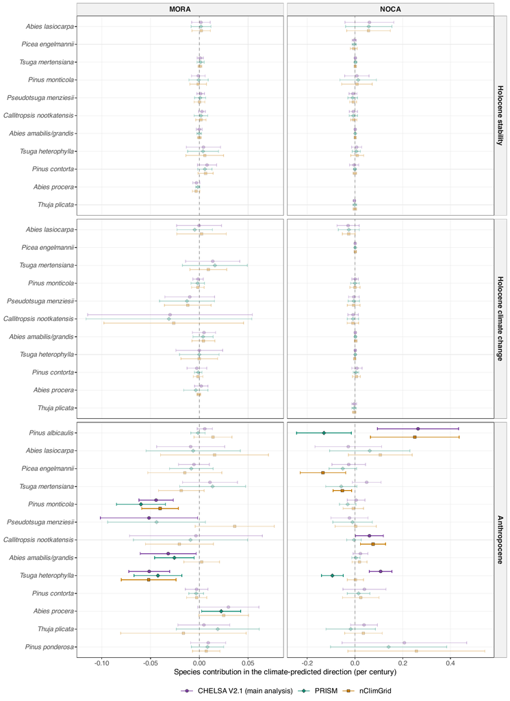

**Fig. S28. Species contributions in the climate-predicted direction with the three climate products.** Mean contribution per century of each species to the community change in the climate-predicted direction, with its 95% confidence interval, as in Fig. 7, for each park (columns) and period type (rows). Species are ordered by elevation as in Fig. 7, and species absent from a park and period type are left out. Means whose interval includes zero are faded. The dashed vertical line marks zero. Purple circles: CHELSA V2.1 (main analysis). Green diamonds: PRISM. Orange squares: nClimGrid. Script: `R/figures/supp_climate_product_sensitivity.R`.